# Wining and Dining: Data Science Edition

Your friend from school has just returned from their gap year as a [WWOOF-er](https://wwoof.org.uk/) in a small estate outside of Lyon. They claim that there’s nothing quite like a French wine. They’re better, more expensive, and they won’t let you forget it!

But, you have your doubts:

> *Are French wines really the best, or are they just more expensive for the same quality?*

So you, now a freshly minted data scientist, decide to moonlight as a data sommelier. Your overarching mission: shed some light on this question.

# 0 The Data

You find a nice dataset of [all the wine ratings](https://www.kaggle.com/zynicide/wine-reviews) from *WineMag*, a lifestyle magazine about wine & winemaking, and get to work.

```r
library(tidyverse)
wines = read_csv('http://ljwolf.org/teaching/gds/wines.csv')
wines %>% head(1) %>% knitr::kable()
```

| X1 | country | description | designation | points | price | province | region_1 | region_2 | variety | winery |
| --- | --- | --- | --- | --- | --- | --- | --- | --- | --- | --- |
| 0 | US | This tremendous 100% varietal wine hails from Oakville and was aged over three years in oak. Juicy red-cherry fruit and a compelling hint of caramel greet the palate, framed by elegant, fine tannins a… | Martha’s Vineyard | 96 | 235 | California | Napa Valley | Napa | Cabernet Sauvignon | Heitz |

As you can see, the data contains information on the `country` the wine is from, as well as the `province`, the macro-level `region` (which is below the `province`) and the micro-level `region_2` (which is below the `region_1`). The `designation` represents the part of the vinyard where the vintner claims the wine comes from. The `price` is the price (in dollars) of the wine. The `points` are the rating of the wine, given by *WineMag*’s judges. Finally, the `variety` reflects the grape (or grapes) used to make the wine, and the `winery` reflects the name of the winery that grew the wine.

# 1 Exploration & Visualization

This section, please use tidy transformation, like `group_by` and `summarize`, to obtain the answers to these questions.

## 1.1

What is your best guess about the price and rating of wines from each country?

```r
wines %>% group_by(country) %>% summarize(price = mean(price), rating=mean(points))
```

```
## # A tibble: 5 x 3
##   country price rating
##   <chr>   <dbl>  <dbl>
## 1 Chile    19.3   86.3
## 2 France   45.6   88.6
## 3 Italy    37.5   88.4
## 4 Spain    27.0   86.6
## 5 US       33.7   87.8
```

## 1.2

What is the highest rating attained by a wine in each country?

```r
wines %>% group_by(country) %>% arrange(desc(points)) %>% summarize(first(points))
```

```
## # A tibble: 5 x 2
##   country `first(points)`
##   <chr>             <dbl>
## 1 Chile                95
## 2 France              100
## 3 Italy               100
## 4 Spain                98
## 5 US                  100
```

## 1.3

Using `ggplot`, show me the distribution of the ratings of wines in each country.

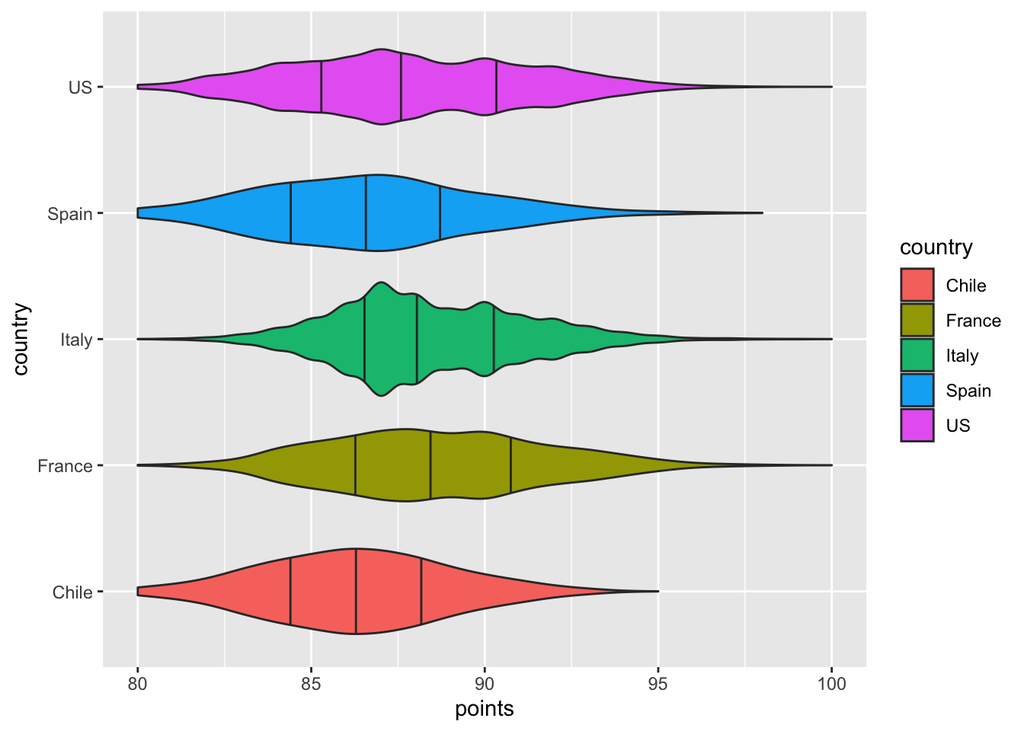

```r
wines %>% ggplot(aes(x=points, y=country, fill=country)) + geom_violin(draw_quantiles = c(.25,.5,.75), adjust=1.5)
```

## 1.4

[Orson Welles disagrees with your friend, and thinks that the US is almost as good as France at making champagne…but he was paid a lot (in free US wine) to say so!](https://www.youtube.com/watch?v=Nvxwf1jxdaM)

Does your dataset agree? Are American champagnes rated as highly (on average) as French champagnes?

Remember: the `variety` column contains the kind of grape that made the wine. And, most Champagne wines are actually `Champagne Blend`, when you’re as pedantic as the typical *WineMag* reader 😁

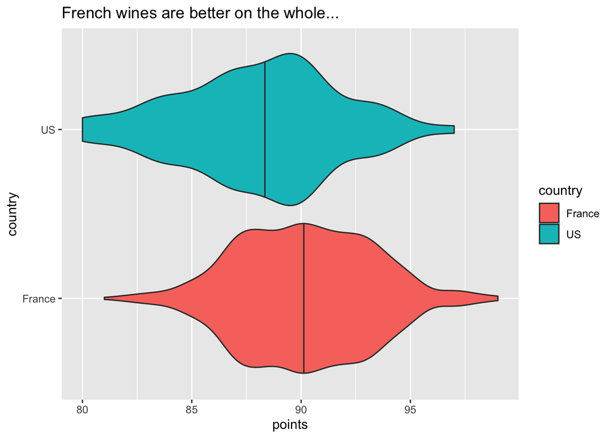

```r
wines %>%
  filter(country == "France" | country == "US") %>%
  filter(variety == "Champagne Blend") %>%
  ggplot(aes(x=points, y=country, fill=country)) +
  geom_violin(draw_quantiles=.5) +
  ggtitle("French wines are better on the whole...")
```

## 1.5 **challenge**

What are the two most common `variety` of wine in each country?

```r
wines %>% group_by(country, variety) %>%
  summarize(count = n()) %>%
  arrange(desc(count)) %>%
  summarize(variety = head(variety, 2))
```

```
## # A tibble: 10 x 2
## # Groups:   country [5]
##    country variety
##    <chr>   <chr>
##  1 Chile   Cabernet Sauvignon
##  2 Chile   Chardonnay
##  3 France  Chardonnay
##  4 France  Bordeaux-style Red Blend
##  5 Italy   Red Blend
##  6 Italy   Sangiovese
##  7 Spain   Tempranillo
##  8 Spain   Red Blend
##  9 US      Pinot Noir
## 10 US      Cabernet Sauvignon
```

# 2 Who has the best wine?

Fit a standard linear model predicting `points` using `country`. According to this model, which country has the most highly rated wines? Is this significant?

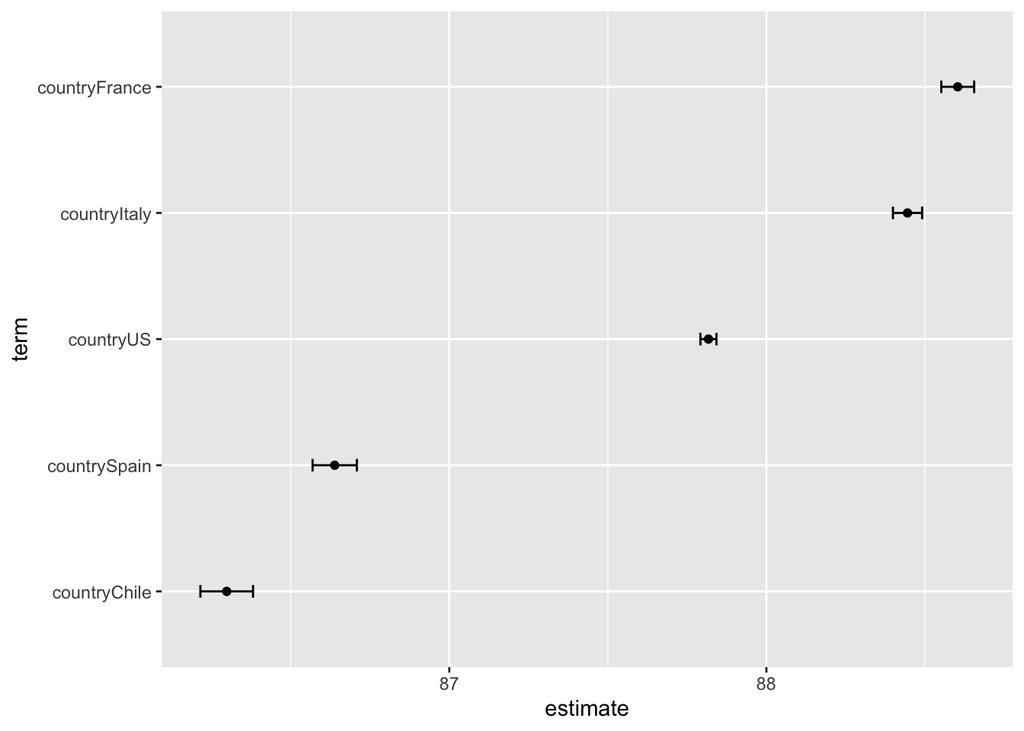

```r
quality_model = lm(points ~ 0 + country, data=wines)
broom::tidy(quality_model, conf.int=T) %>%
  mutate(term = fct_reorder(as.factor(term), estimate))%>%
  ggplot(aes(x=estimate, y=term, xmin=conf.low, xmax=conf.high, height=.1)) +
  geom_errorbarh() + geom_point()
```

*France is best, and Italy, while close, is still clearly worse on average!*

# 3 What is the relationship between price and quality?

Look at the plot showing the relationship between price and quality for each country in the data.

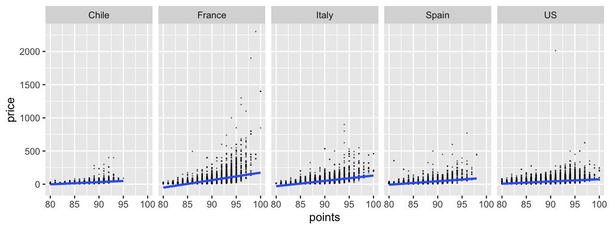

```r
ggplot(wines, aes(x=points, y=price)) +
  geom_point(alpha=.5, lwd=0) +
  geom_smooth(method=lm) +
  facet_grid(~country)
```

## 3.1

From the scatterplot above, does the relationship between price and rating appear to be constant over countries? Does the relationship appear to be linear?

*It looks nonlinear, as well as varying by country.*

## 3.2

Fit a multilevel model predicting the `price` using `points` that allows the slope and intercept to vary by `country`.

Remember to center your X variables when running multilevel models! This improves the numerical stability of the estimating algorithms, and makes it easier to interpret $\alpha$ as “the mean of $y$ when $x$ is at its mean.”

```r
library(lme4)
countries = lmer(price ~ 1 + points + (1 + points | country),
                 data=wines %>%
                   mutate(points = points - mean(points)))
```

## 3.2.1

In the model from 3.2, which country has the lowest baseline price for an average-rated wine? Is it statistically significantly different from the other countries? Briefly interpret what this means in real world terms.

*Yes! Chile is cheap, and unusually so.*

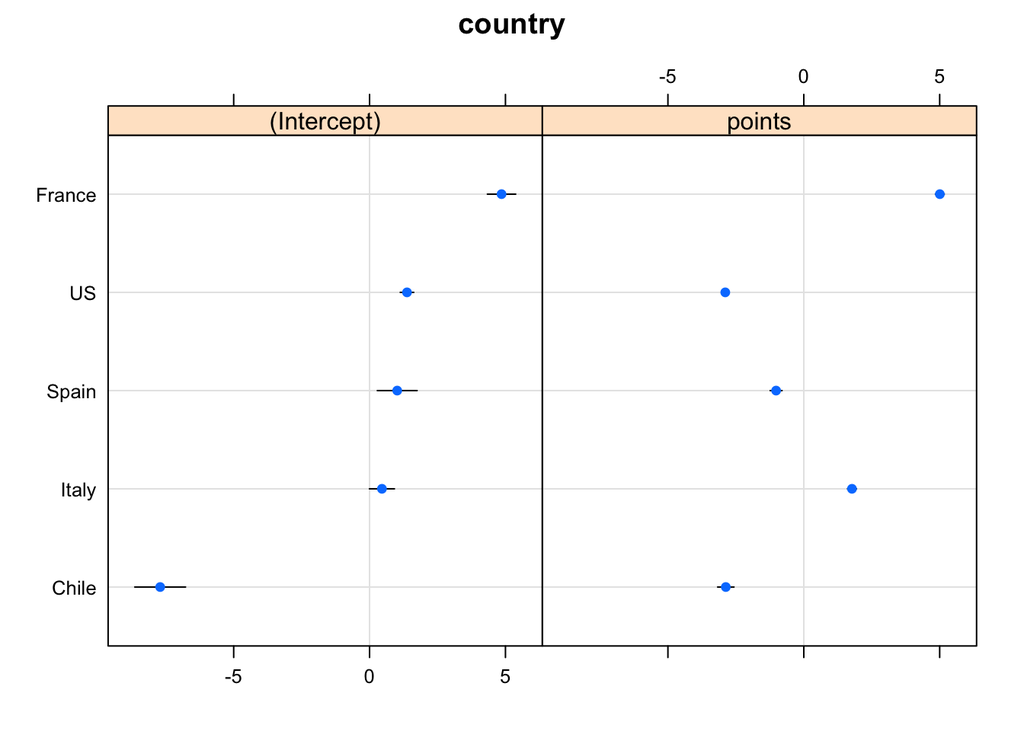

```r
lattice::dotplot(ranef(countries))
```

### 3.2.2

In the model from 3.2, which country pays the highest “premium” for higher-rated wine? Is this statistically significantly different from the other countries? Briefly interpret what this means in real world terms.

Another way of phrasing this is: which country’s prices rise the fastest for each point of rating? Who’s over-charging?

*Yes! French wines make you pay way more for quality!*

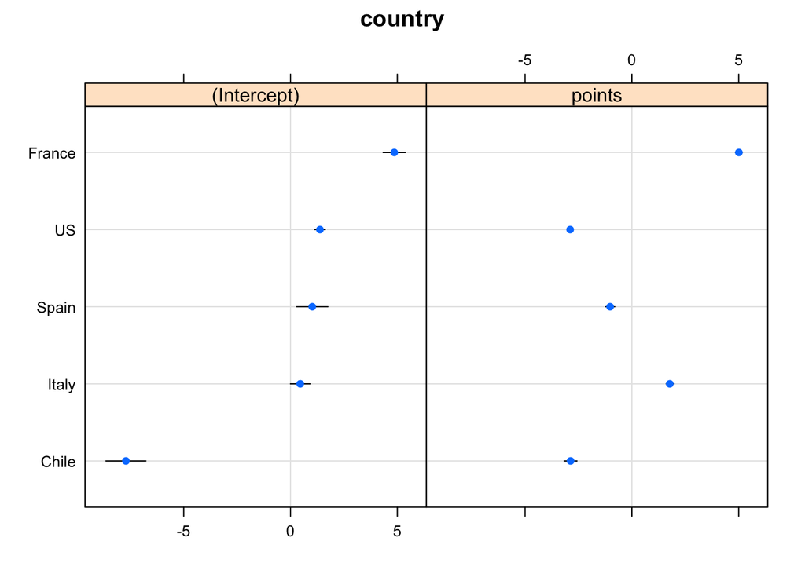

```r
lattice::dotplot(ranef(countries))
```

## 3.3

Given your interpretations from Section 3.2, is French wine higher quality, or just overpriced?

It’s also ok if the true answer is somewhere in between!

## 3.4 **Challenge**

Your friend says they bought a 100-point wine for about $70, but are not sure where it is from.

You use your model model to predict the price of a 100-point wine in every country, and find that it might have come from one of two countries. Given what you have done in Section 1 and here, which country do you think is more likely and why?

Remember that you may have centered your variables! 100 points is *not* the same as 100 points above the mean rating!

```r
scenario = data.frame(country = unique(wines$country),
                              points=100-mean(wines$points))
scenario %>%
  mutate(prediction = predict(countries, scenario)) %>%
  arrange(prediction) %>%
  knitr::kable()
```

| country | points | prediction |
| --- | --- | --- |
| Chile | 12.13683 | 65.83782 |
| US | 12.13683 | 74.67830 |
| Spain | 12.13683 | 97.01974 |
| Italy | 12.13683 | 130.33776 |
| France | 12.13683 | 173.98582 |

*It’s either from Chile or the US. Given the fact that **no wine in our dataset** scored over 95 from Chile, it’s probably from the US.*

# 4 Can we predict where a wine comes from?

Using logistic regression…

## 4.1

Fit a model predicting whether a wine is from France using the wine’s price and rating. In this model,

```r
is_french = glm(country == "France" ~ price + points,
                data=wines, family=binomial())
summary(is_french)
```

```
##
## Call:
## glm(formula = country == "France" ~ price + points, family = binomial(),
##     data = wines)
##
## Deviance Residuals:
##     Min       1Q   Median       3Q      Max
## -4.1958  -0.5524  -0.5063  -0.4694   2.2300
##
## Coefficients:
##               Estimate Std. Error z value Pr(>|z|)
## (Intercept) -6.0802333  0.2682176  -22.67   <2e-16 ***
## price        0.0053314  0.0002458   21.69   <2e-16 ***
## points       0.0456088  0.0030865   14.78   <2e-16 ***
## ---
## Signif. codes:  0 '***' 0.001 '**' 0.01 '*' 0.05 '.' 0.1 ' ' 1
##
## (Dispersion parameter for binomial family taken to be 1)
##
##     Null deviance: 86724  on 109633  degrees of freedom
## Residual deviance: 85342  on 109631  degrees of freedom
## AIC: 85348
##
## Number of Fisher Scoring iterations: 4
```

### 4.1.1

Do more expensive wines tend to be from France?

*Yes! The effect of `price` is significant and positive.*

### 4.1.2

Do more highly-rated wines tend to be from France? ’

*Yes! The effect of `points` is significant and positive.*

### 4.1.3

Using a cutoff of .2, show me the confusion matrix. How many French wines does our model classify correctly?

```r
wines %>% mutate(predict_p = predict(is_french, type='response'),
                 is_French = country == "France") %>%
  mutate(predict_French = predict_p > .2) %>%
  xtabs(~ predict_French + is_French, data=.)
```

```
##               is_French
## predict_French FALSE  TRUE
##          FALSE 91695 13372
##          TRUE   3154  1413
```

This question asks for the sensitivity. This is very bad in our model: 0.1.

## 4.2

Now, fit a model predicting whether or not a wine is from the United States using the wine’s price and rating. In this model,

```r
is_US = glm(country == "US" ~ price + points,
                data=wines, family=binomial())
summary(is_US)
```

```
##
## Call:
## glm(formula = country == "US" ~ price + points, family = binomial(),
##     data = wines)
##
## Deviance Residuals:
##    Min      1Q  Median      3Q     Max
## -1.319  -1.301   1.050   1.062   2.576
##
## Coefficients:
##               Estimate Std. Error z value Pr(>|z|)
## (Intercept)  0.3787892  0.1840676   2.058   0.0396 *
## price       -0.0017931  0.0002011  -8.917   <2e-16 ***
## points      -0.0005437  0.0021310  -0.255   0.7986
## ---
## Signif. codes:  0 '***' 0.001 '**' 0.01 '*' 0.05 '.' 0.1 ' ' 1
##
## (Dispersion parameter for binomial family taken to be 1)
##
##     Null deviance: 150023  on 109633  degrees of freedom
## Residual deviance: 149909  on 109631  degrees of freedom
## AIC: 149915
##
## Number of Fisher Scoring iterations: 4
```

### 4.2.1

Do more expensive wines tend to be from the US?

*No! In fact, price is negatively associated with being a US wine!*

### 4.2.2

*No! Rating is not significantly associated with being a US wine.*

## 41.3 **Challenge**

At what threshold is the accuracy maximized in each model?

Which model can attain the highest accuracy: the model predicting French wine, or the model predicting American wine?

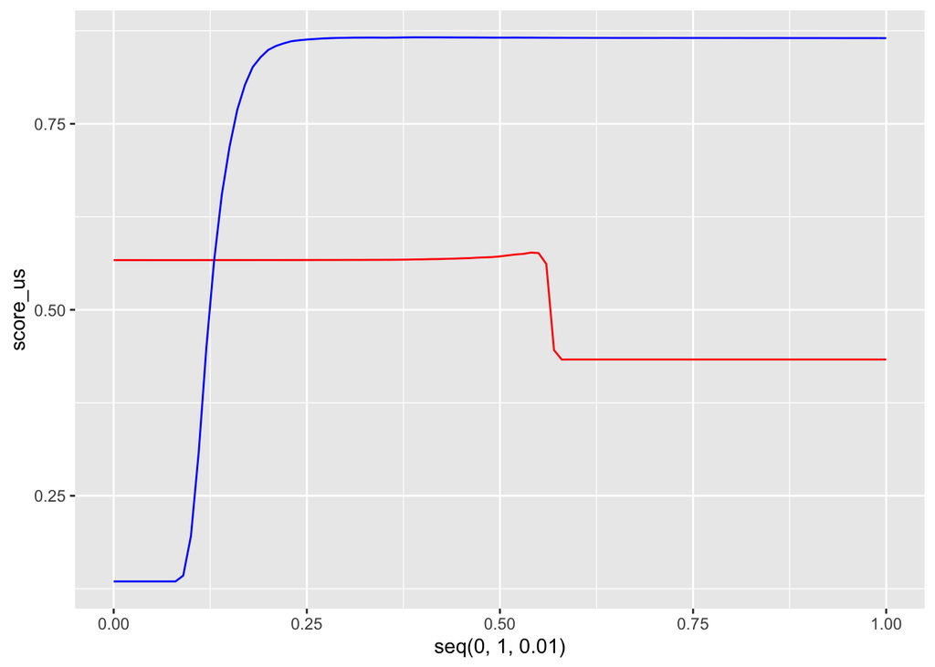

```r
acc <- function(threshold, model=is_france,
                     target="France", data=wines){
  outcome = data %>% mutate(predict_p = predict(model, type='response'),
                  outcome = (country == target)) %>%
    mutate(predict_b = predict_p > threshold)
  right = outcome %>% filter(outcome == predict_b) %>% nrow()

  return(right/nrow(outcome))
}

score_us <- c()
score_france <- c()

for(threshold in seq(0,1,.01)){
  score_us <- c(score_us, acc(threshold,
                          model=is_US,
                          target='US'))
  score_france <- c(score_france, acc(threshold,
                                  model=is_french,
                                  target="France"))
}

ggplot(mapping=aes(x=seq(0,1,.01))) +
  geom_line(mapping=aes(y=score_us), color='red') +
  geom_line(mapping=aes(y=score_france), color='blue')
```

The best accuracy for the US model happens around a threshold of .54.

The best accuracy for the French model happens at .39, but gets there at around .25.